# Gentle Introduction to ggplot2

Jim Albert

#### Introduction

`ggplot2` is a R package for graphing data based on the “The Grammar of Graphics” framework introduced by Leland Wilkinson. This package is used to construct all of the graphs for the book *Visualizing Baseball*. The purpose of this document to introduce ggplot2 for a familiar baseball dataset. In this document, I introduce the basic framework and illustrate the use of ggplot2 to construct graphs for different types of variables.

#### Some Baseball Data

Collect hitting data for all teams in the 2015 baseball season. For each team, I compute its slugging percentage `SLG` and its on-base percentage `OBP`.

```r
library(dplyr)
library(Lahman)
teams2015 <- filter(Teams, yearID == 2015)
names(teams2015)[18:19] <- c("X2B", "X3B")
teams2015$SF <- as.numeric(teams2015$SF)
teams2015$HBP <- as.numeric(teams2015$HBP)
teams2015 <- mutate(teams2015,
                    X1B = H - X2B - X3B - HR,
                    TB = X1B + 2 * X2B + 3 * X3B + 4 * HR,
                    SLG = TB / AB,
                    OBP = (H + BB + HBP) /
                      (AB + BB + HBP + SF))
```

#### Three Basic Components of a ggplot2 Graph

To construct a graph using `ggplot2`, one needs …

1. A **data frame** that contains the data that you want to graph.
2. **Aesthetics** or roles assigned to particular variables in the data frame.
3. A **geometric object** (or **geom** for short) which is what you are plotting.

For example, suppose we wish to construct a scatterplot of the on-base percentage and the slugging percentages for all teams in the 2015 season.

1. The data frame `teams2015` contains the data and `OBP` and `SLG` are the variables of interest.
2. To construct a scatterplot, you need to have a variable on the horizontal axis (`x`) and a variable on the vertical axis (`y`). If I want `OBP` to be the horizontal axis variable and `SLG` the vertical axis variable, I would assign the aethetics `OBP` to `x` and `SLG` to `y`.

Steps 1 and 2 are communicated by the command

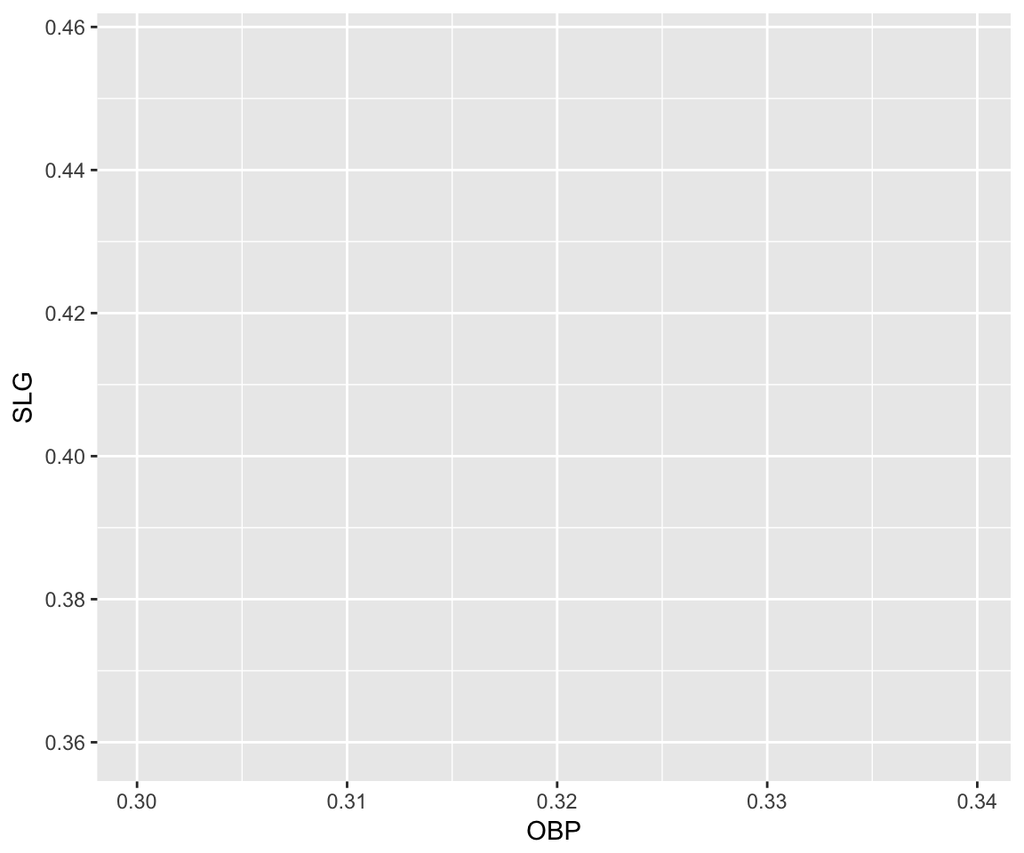

```r
library(ggplot2)
ggplot(data=teams2015, aes(x=OBP, y=SLG))
```

The `ggplot2` function only sets up the axis – it does not plot anything. To construct a scatterplot, we need to add a point geometric object which is the function `geom_point`. Now we see the scatterplot. There is a clear positive association between a team’s OBP and its SLG.

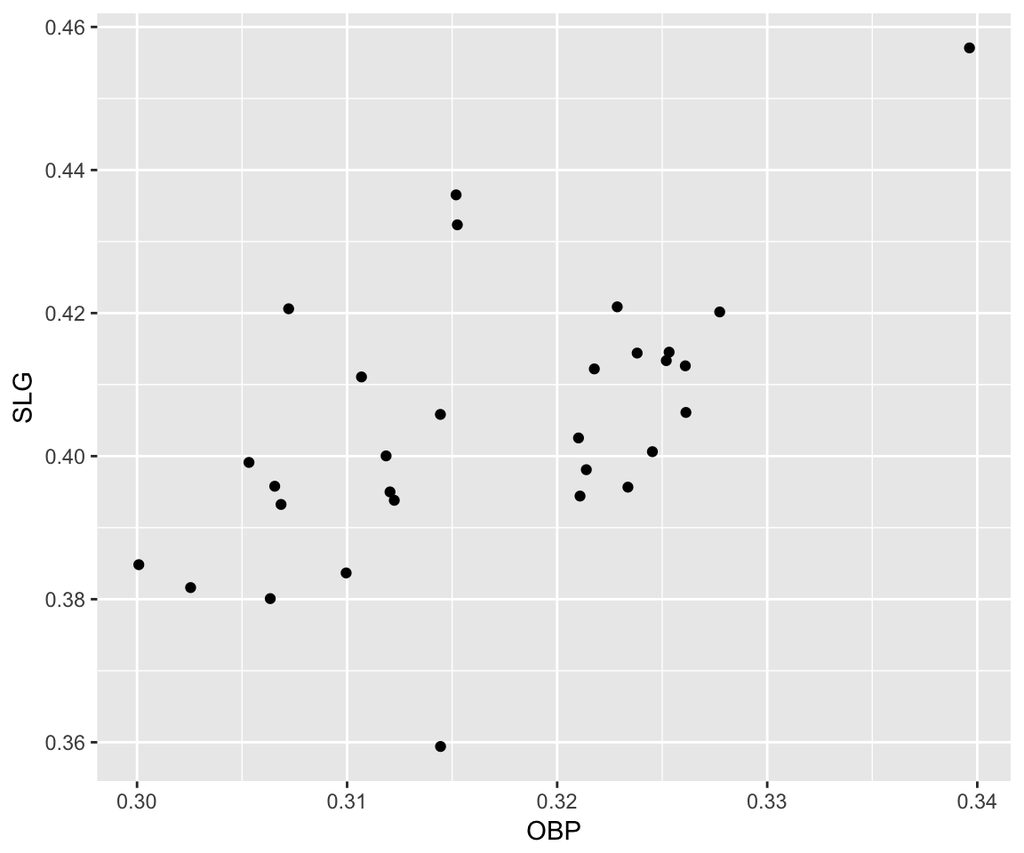

```r
ggplot(data=teams2015, aes(x=OBP, y=SLG)) +
  geom_point()
```

#### Other Aesthetics (color, shape, and size)

There are other roles or aesthetics that you can assign to variables.

For example, the variable `lgID` gives the league (`AL` or `NL`). We can assign `lgID` to the **color** aesthetic – so the points are colored by the league variable. This tells us that the team with the highest OBP and highest SLG was from the American League.

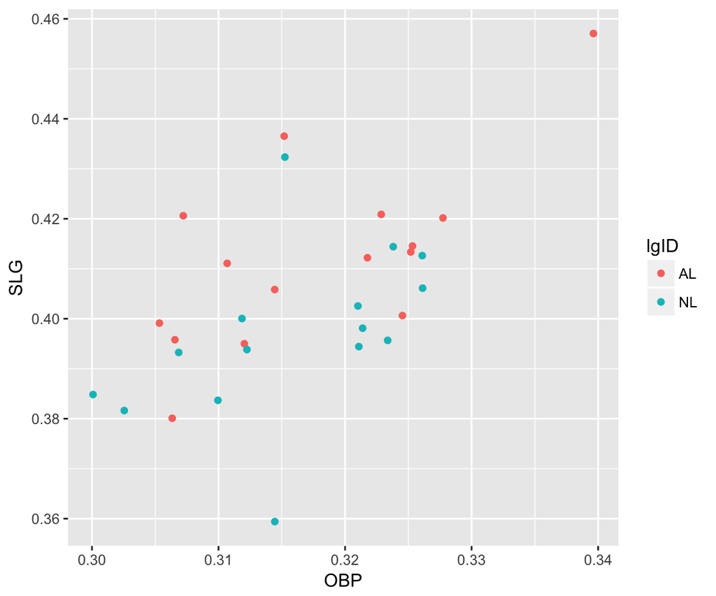

```r
ggplot(data=teams2015,
       aes(x=OBP, y=SLG, color=lgID)) +
  geom_point()
```

There are other aesthetics like **shape** and **size**.

Here I can use different plotting symbols for each league by assigning `lgID` to the shape aesthetic. Personally, I think the different shapes are harder to distinguish than the different colors.

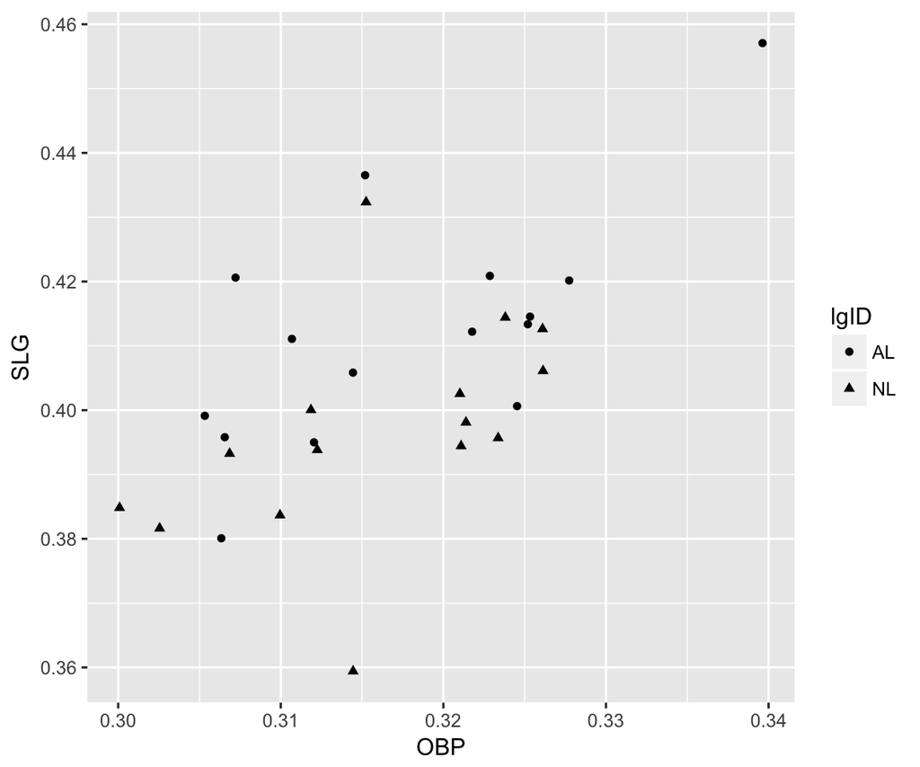

```r
ggplot(data=teams2015,
       aes(x=OBP, y=SLG, shape=lgID)) +
  geom_point()
```

The variable `W` is the number of team wins. Here I assign the variable `W` to the size aesthetic. Notice that the team with the highest OBP and SLG values appeared to win a lot of games in the 2015 season.

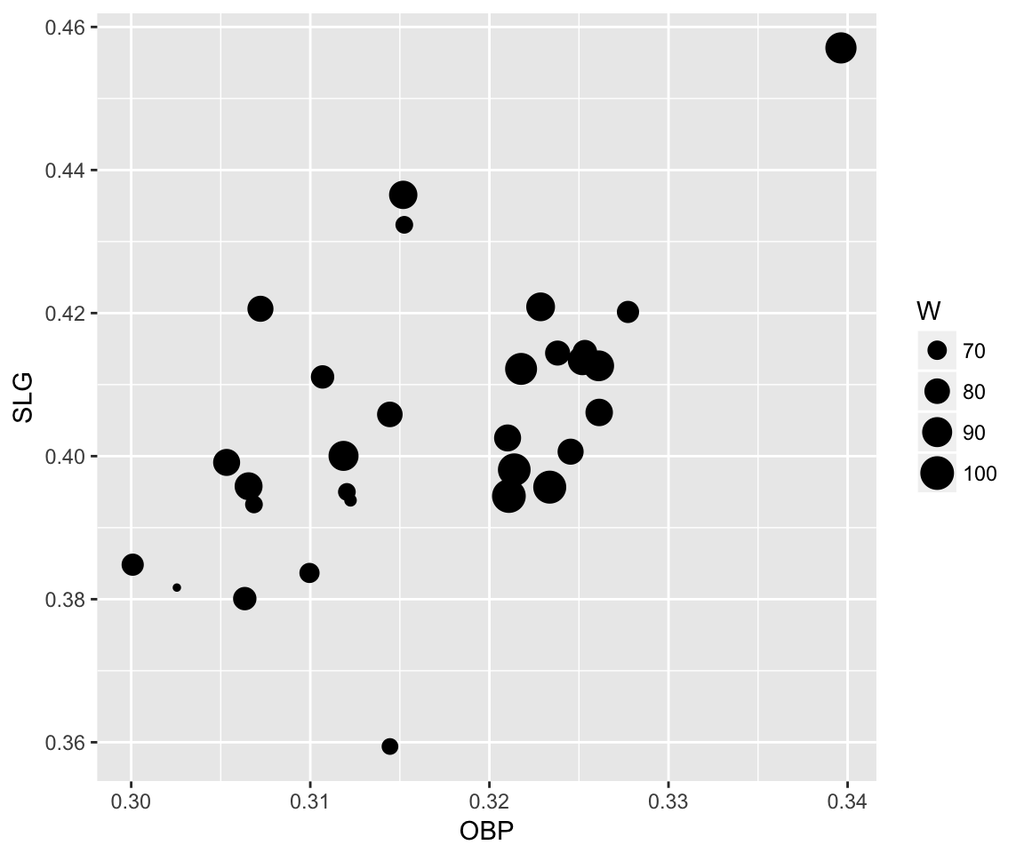

```r
ggplot(data=teams2015,
       aes(x=OBP, y=SLG, size=W)) +
  geom_point()
```

#### Facetting

In ggplot2, it is easy to break the plot into several panels defined by a categorical variable – these different panels are called **facets**. Suppose I want to construct panels of scatterplots of `OBP` by `SLG`, where the panels are defined by the league variable.

From this graph, it appears that the AL teams generally had higher SLG values than the NL teams.

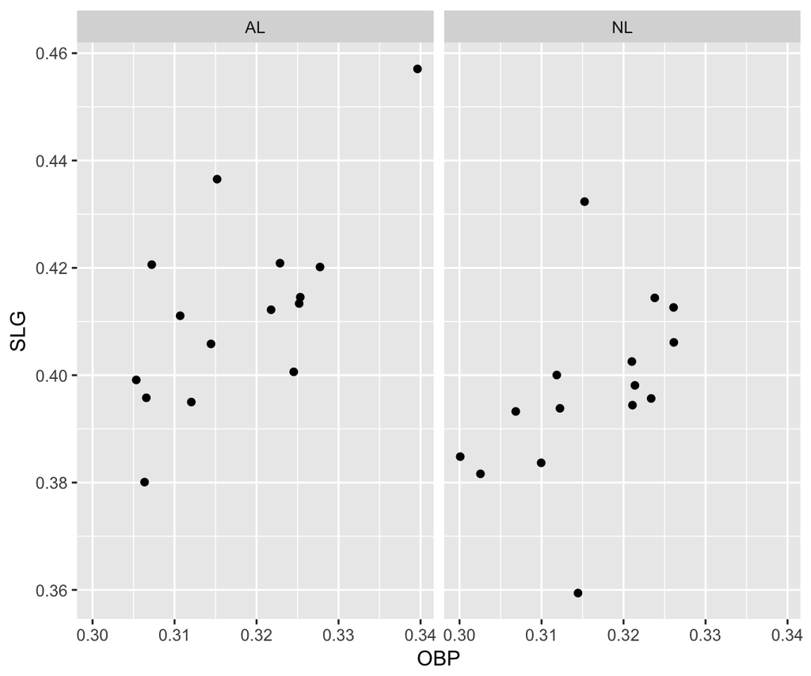

```r
ggplot(data=teams2015,
       aes(x=OBP, y=SLG)) +
  geom_point() +
  facet_grid(~ lgID)
```

#### Some Plot Geoms

There are many possible geometric objects (geoms) that one can use depending on the number of variables and variable types.

##### A Single Numeric Variable

Suppose one wants to construct a histogram of the OBP’s for the 30 times. Here the single aesthetic is x and we use `geom_histogram`. I indicate that we want to apply five bins in the histogram.

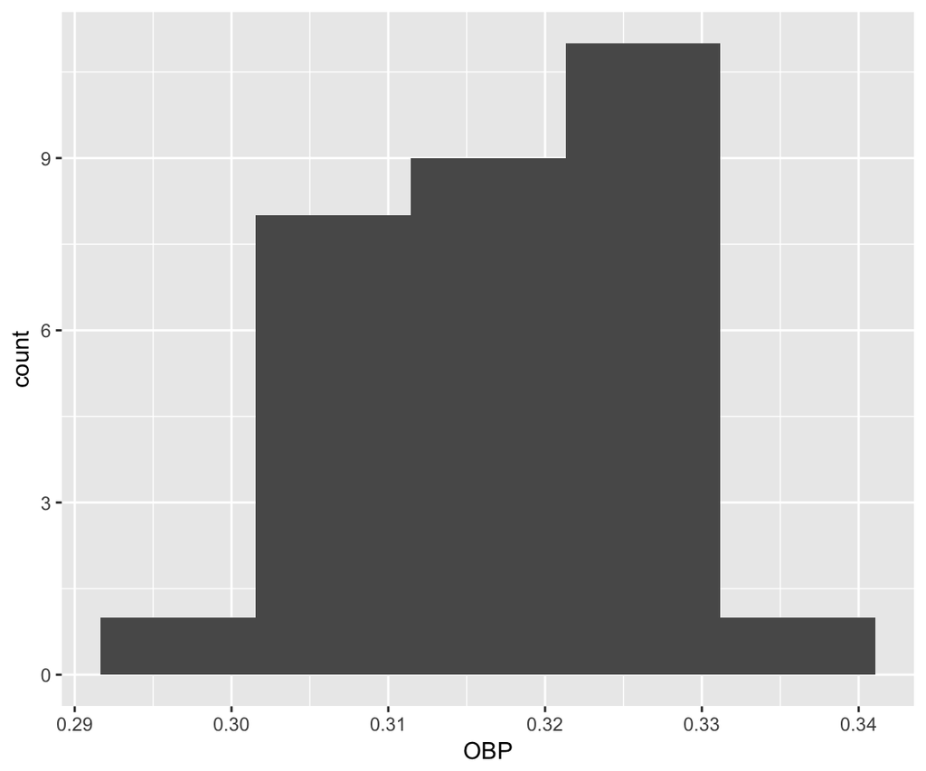

```r
ggplot(data=teams2015, aes(x=OBP)) +
  geom_histogram(bins=5)
```

##### A Single Categorical Variable

A bar chart is a graph of a single categorical variable that we can produce using the `geom_bar` geom. This graph confirms that there are 15 teams in each league.

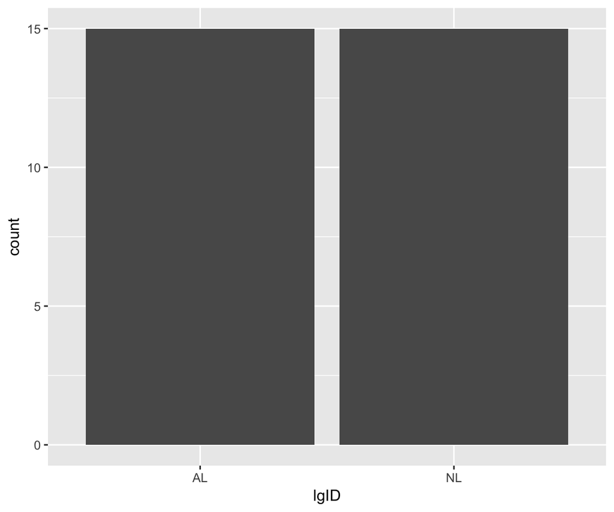

```r
ggplot(data=teams2015, aes(x=lgID)) + geom_bar()
```

##### One Categorical Variable and One Numeric Variable

We said earlier that it appeared that the slugging percentages were greater for teams in the American League. A more direct way to graphically compare the two groups of SLG values is by parallel boxplots. Here we assign the x aesthetic to `lgID`, the y aesthetic to `SLG`, and use the `geom_boxplot` geom.

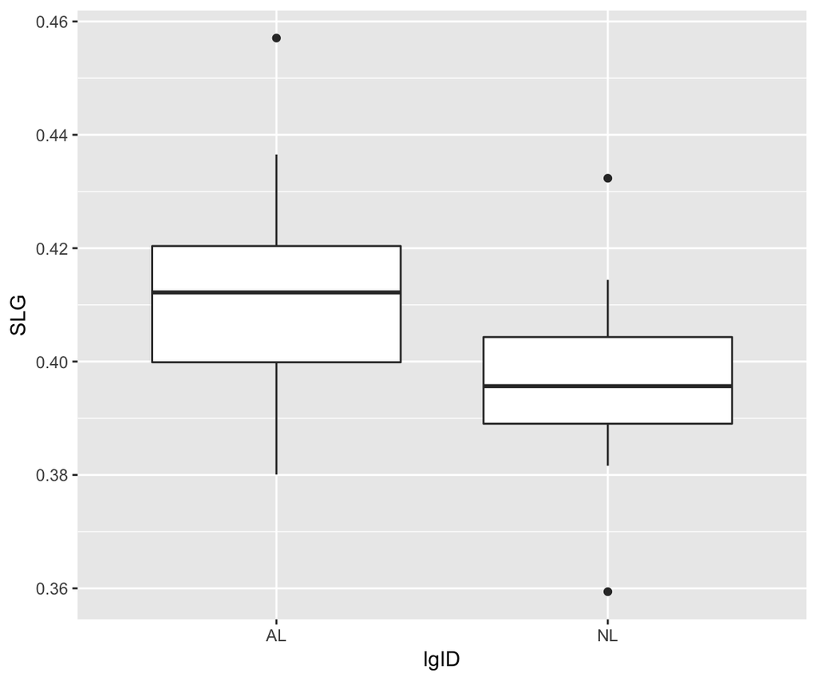

```r
ggplot(data=teams2015, aes(x=lgID, y=SLG)) +
  geom_boxplot()
```

Another geom that one can use in this scenario is `geom_jitter` which produces jittered points. The `width` option controls the width of the horizontal range of the jittering.

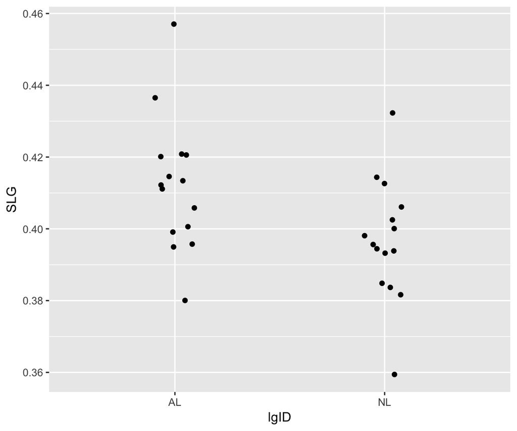

```r
ggplot(data=teams2015, aes(x=lgID, y=SLG)) +
  geom_jitter(width=0.1)
```

#### Modifying the Axes

In ggplot2, it is possible to modify all aspects of the graph. I illustrate some basic modificaitons here. I use the `ggtitle` function to add a plot title, and use the `ylab` and `xlab` functions to add x and y labels.

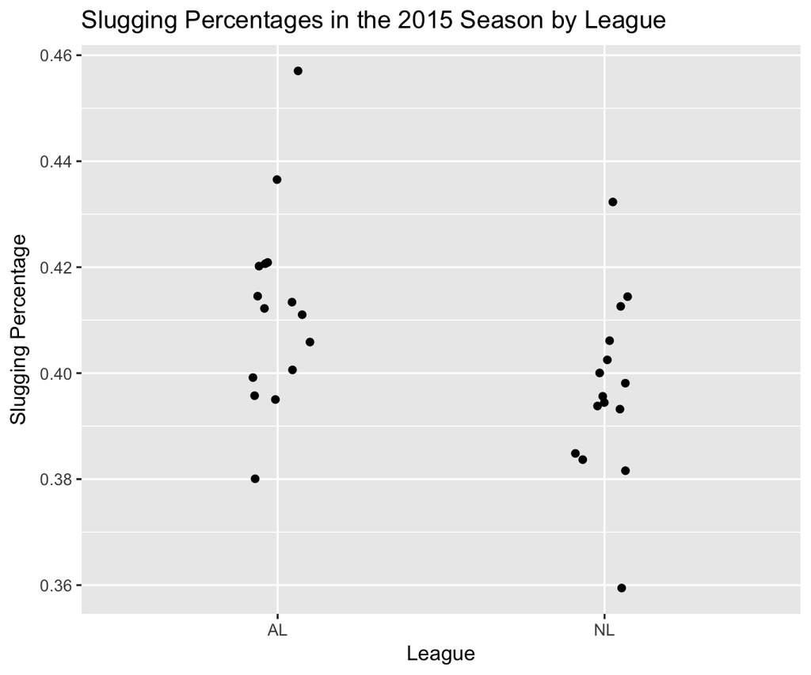

```r
ggplot(data=teams2015, aes(x=lgID, y=SLG)) +
  geom_jitter(width=0.1) +
  ggtitle("Slugging Percentages in the 2015 Season by League") +
  xlab("League") + ylab("Slugging Percentage")
```

#### Learning More About ggplot2

Hopefully this introduction gets you interested in trying out ggplot2 for your own graphs. I encourage you to try out some of the ggplot2 example scripts for the different chapters and then apply ggplot2 for your own problems.